Alexis LE GUELTE, Chelsea Christla NJOMGANG WETE, Thelma TIJOU, Youssouf YIAGNIGNI TOUONDOUNKO (IRO2-Group6)

# Basic imports

```python
#Imports & configuration
import os, math, warnings
from pathlib import Path

import numpy as np
import pandas as pd
import matplotlib.pyplot as plt

from sklearn.preprocessing import StandardScaler
from sklearn.model_selection import GroupShuffleSplit, train_test_split
from sklearn.ensemble import RandomForestClassifier
from sklearn.metrics import classification_report, confusion_matrix, roc_auc_score, RocCurveDisplay

warnings.filterwarnings("ignore")
plt.rcParams["figure.figsize"] = (10,6)

# Notebook folder (put "." if the notebook is in the same folder as the CSVs)
BASE = Path(".")

# We list the CSV files available in the folder
csv_files = sorted(p.name for p in BASE.glob("*.csv"))
csv_files
```

```
['IMU_10Hz.csv',
 'IMU_20Hz_freq_drop.csv',
 'IMU_20Hz_freq_drop_2.csv',
 'IMU_2Hz.csv',
 'IMU_Acc_Gyro_20Hz.csv',
 'IMU_earthquake.csv',
 'IMU_extra_weigth.csv',
 'IMU_hitting_arm.csv',
 'IMU_hitting_platform.csv',
 'IMU_magnet.csv',
 'nicla.csv',
 'quaternions_20Hz.csv',
 'quaternions_no_idle.csv',
 'right_arm.csv']
```

# 1 - Descriptive data analysis

```python
# Columns common to IMUs (some files do not have everything)
COMMON = ['time','accX','accY','accZ','gyroX','gyroY','gyroZ','magX','magY','magZ','name']

def read_common(path, nrows=None):
    """Loads our CSV and keeps only known IMU columns + source."""
    df = pd.read_csv(path, nrows=nrows)
    keep = [c for c in COMMON if c in df.columns]
    df = df[keep].copy()
    for c in df.columns:
        if c not in ('time','name'):
            df[c] = pd.to_numeric(df[c], errors='coerce')
    df['source'] = Path(path).name
    return df

def add_norms(df):
    """Add acc/gyro/mag standards if possible."""
    for name, cols in {
        'acc_norm':  ['accX','accY','accZ'],
        'gyro_norm': ['gyroX','gyroY','gyroZ'],
        'mag_norm':  ['magX','magY','magZ'],
    }.items():
        have = [c for c in cols if c in df.columns]
        if len(have)==3:
            df[name] = np.sqrt((df[have]2).sum(axis=1))
    return df

# Light sample for EDA
eda_frames = []
for f in csv_files:
    if f.lower().startswith("quaternion"):    # we exclude quaternions for now
        continue
    try:
        eda_frames.append(read_common(BASE/f, nrows=5000))
    except Exception as e:
        print(f"[WARN] {f}: {e}")

eda = pd.concat(eda_frames, ignore_index=True, sort=False)
eda = add_norms(eda)

# Size & columns per file
sizes = (eda.groupby('source')['source']
             .size()
             .rename('rows')
             .to_frame())
sizes['cols_present'] = eda.groupby('source').apply(lambda g: list(g.columns))
sizes
```

```
[WARN] nicla.csv: Error tokenizing data. C error: Expected 2 fields in line 3, saw 9
```

| source | rows | cols_present |
| --- | --- | --- |
| IMU_10Hz.csv | 5000 | [time, accX, accY, accZ, gyroX, gyroY, gyroZ, ... |
| IMU_20Hz_freq_drop.csv | 5000 | [time, accX, accY, accZ, gyroX, gyroY, gyroZ, ... |
| IMU_20Hz_freq_drop_2.csv | 5000 | [time, accX, accY, accZ, gyroX, gyroY, gyroZ, ... |
| IMU_2Hz.csv | 5000 | [time, accX, accY, accZ, gyroX, gyroY, gyroZ, ... |
| IMU_Acc_Gyro_20Hz.csv | 5000 | [time, accX, accY, accZ, gyroX, gyroY, gyroZ, ... |
| IMU_earthquake.csv | 5000 | [time, accX, accY, accZ, gyroX, gyroY, gyroZ, ... |
| IMU_extra_weigth.csv | 5000 | [time, accX, accY, accZ, gyroX, gyroY, gyroZ, ... |
| IMU_hitting_arm.csv | 5000 | [time, accX, accY, accZ, gyroX, gyroY, gyroZ, ... |
| IMU_hitting_platform.csv | 5000 | [time, accX, accY, accZ, gyroX, gyroY, gyroZ, ... |
| IMU_magnet.csv | 5000 | [time, accX, accY, accZ, gyroX, gyroY, gyroZ, ... |
| right_arm.csv | 5000 | [time, accX, accY, accZ, gyroX, gyroY, gyroZ, ... |

[figure not shown]

[figure not shown]

[figure not shown]

```python
# Distributions (acc_norm / gyro_norm / mag_norm) per file
for col in ['acc_norm','gyro_norm','mag_norm']:
    if col in eda:
        plt.figure()
        for s, g in eda.groupby('source'):
            g[col].dropna().sample(min(2000, len(g)), random_state=0).plot(kind='hist', bins=60, alpha=0.35, label=s)
        plt.title(f"Distribution of {col}")
        plt.xlabel(col); plt.ylabel("comptes"); plt.legend()
        plt.show()
```

```python
# Robust estimation of sample rate per file
def estimate_hz(df):
    if 'time' not in df:
        return np.nan
    #Float test (timestamps in seconds)
    ts = pd.to_numeric(df['time'], errors='coerce')
    if ts.notna().sum() >= 3:
        d = np.diff(ts.dropna().values)
        d = d[d>0]
        if len(d):
            med = np.median(d)
            return round(1.0/med, 3) if med>0 else np.nan
    #Datetime Test
    t = pd.to_datetime(df['time'], errors='coerce', utc=True, infer_datetime_format=True)
    if t.notna().sum() >= 3:
        d = np.diff(t.dropna().astype('int64').values/1e9)
        d = d[d>0]
        if len(d):
            med = np.median(d)
            return round(1.0/med, 3) if med>0 else np.nan
    return np.nan

hz = eda.groupby('source').apply(estimate_hz).rename('Hz').reset_index()
hz
```

|  | source | Hz |
| --- | --- | --- |
| 0 | IMU_10Hz.csv | 0.0 |
| 1 | IMU_20Hz_freq_drop.csv | 0.0 |
| 2 | IMU_20Hz_freq_drop_2.csv | 0.0 |
| 3 | IMU_2Hz.csv | 0.0 |
| 4 | IMU_Acc_Gyro_20Hz.csv | 0.0 |
| 5 | IMU_earthquake.csv | 0.0 |
| 6 | IMU_extra_weigth.csv | 0.0 |
| 7 | IMU_hitting_arm.csv | 0.0 |
| 8 | IMU_hitting_platform.csv | 0.0 |
| 9 | IMU_magnet.csv | 0.0 |
| 10 | right_arm.csv | NaN |

# 2 - Implementation of the necessary pre-processing

```python
# Labeling from file name
ANOMYMS = ['earthquake','hitting_arm','hitting_platform','extra_weigth','magnet']
def label_from_name(name: str) -> int:
    n = name.lower()
    return int(any(k in n for k in ANOMYMS))

# Load all IMU files (except quaternions for now) and prepare features
all_frames = []
for f in csv_files:
    if f.lower().startswith("quaternion"):
        continue
    try:
        df = read_common(BASE/f, nrows=None)   #set nrows=200_000 if you want to go faster
        df['label'] = label_from_name(f)
        all_frames.append(df)
    except Exception as e:
        print(f"[WARN] {f}: {e}")

raw = pd.concat(all_frames, ignore_index=True, sort=False)
raw = add_norms(raw)

# Available feature columns
feature_cols = [c for c in ['accX','accY','accZ','gyroX','gyroY','gyroZ','magX','magY','magZ',
                            'acc_norm','gyro_norm','mag_norm'] if c in raw.columns]
raw = raw.dropna(subset=feature_cols, how='all').reset_index(drop=True)

# Normalization per file (avoids sensor calibration bias)
scalers = {}
def scale_by_source(df, cols):
    parts = []
    for s, g in df.groupby('source', sort=False):
        sc = StandardScaler()
        g = g.copy()
        g[cols] = sc.fit_transform(g[cols].fillna(method='ffill').fillna(method='bfill').fillna(0.0))
        scalers[s] = sc
        parts.append(g)
    return pd.concat(parts, ignore_index=True)

proc = scale_by_source(raw, feature_cols)
proc.head()
```

```
[WARN] nicla.csv: Error tokenizing data. C error: Expected 2 fields in line 3, saw 9
```

|  | time | accX | accY | accZ | gyroX | gyroY | gyroZ | magX | magY | magZ | name | source | label | acc_norm | gyro_norm | mag_norm |
| --- | --- | --- | --- | --- | --- | --- | --- | --- | --- | --- | --- | --- | --- | --- | --- | --- |
| 0 | 1.686063e+18 | 0.332311 | 0.295862 | -0.018287 | -0.016908 | -0.082141 | -0.000691 | 5.704237 | -1.016025 | 0.078861 | IMU8 | IMU_10Hz.csv | 0 | -0.408627 | -0.941246 | -8.973483 |
| 1 | 1.686063e+18 | 0.354417 | 0.305961 | -0.028482 | -0.010216 | -0.082141 | -0.000691 | -2.555192 | -1.401906 | -0.341769 | IMU8 | IMU_10Hz.csv | 0 | -0.301583 | -0.943433 | -0.483606 |
| 2 | 1.686063e+18 | 0.346521 | 0.302077 | -0.222197 | -0.019138 | -0.082141 | -0.000691 | -2.603093 | -1.403980 | -0.341769 | IMU8 | IMU_10Hz.csv | 0 | -0.346824 | -0.939059 | -0.437803 |
| 3 | 1.686063e+18 | 0.330732 | 0.292755 | -0.212001 | -0.014677 | -0.074408 | -0.000691 | -2.596250 | -1.395682 | -0.349106 | IMU8 | IMU_10Hz.csv | 0 | -0.423648 | -0.942527 | -0.437954 |
| 4 | 1.686063e+18 | 0.344943 | 0.292755 | -0.130437 | -0.012447 | -0.082141 | -0.000691 | -2.568878 | -1.393607 | -0.356442 | IMU8 | IMU_10Hz.csv | 0 | -0.353372 | -0.945621 | -0.454154 |

```python
# Statistical windowing (features on sliding windows)
WIN = 50          #50 samples
OVERLAP = 0.5     # 50% recovery

def window_features(df, cols, win=WIN, overlap=OVERLAP):
    step = max(1, int(win*(1-overlap)))
    N = len(df)
    rows = []
    for start in range(0, N - win + 1, step):
        end = start + win
        sl = df.iloc[start:end]
        row = {}
        for c in cols:
            s = sl[c].values
            row[f'{c}_mean'] = s.mean()
            row[f'{c}_std']  = s.std()
            row[f'{c}_min']  = s.min()
            row[f'{c}_max']  = s.max()
            row[f'{c}_rms']  = np.sqrt((s2).mean())
        # label majority in window
        row['label']  = int(sl['label'].mean() >= 0.5)
        row['source'] = sl['source'].iloc[0]
        rows.append(row)
    return pd.DataFrame(rows)

blocks = []
for s, g in proc.groupby('source', sort=False):
    if len(g) >= WIN:
        blocks.append(window_features(g, feature_cols, win=WIN, overlap=OVERLAP))

dataset = pd.concat(blocks, ignore_index=True, sort=False)
dataset['label'].value_counts()
```

```
label
0    230701
1      2564
Name: count, dtype: int64
```

# 3 - Formalisation of the problem

### 1) Context & Objective

IMU measurements are provided for the UR3e robotic arm, recorded during normal operations such as screw driving, painting, and pick-and-place, as well as during simulated anomalies including earthquake, hitting the arm or platform, added weight, and magnetic interference. The key objective is to develop a TinyML-compatible approach that will result in the detection of these anomalies in real time and the generation of reliable alerts with low computational overhead and minimum latency.

Machine learning formulation → *binary classification per window*

- Input: Statistical features extracted from sliding windows over IMU time series.
- Output: y ∈ {0,1}, where 0=normal, 1=anomaly.

### 2) Observation Unit (Time Windowing)

The input data files are sampled at various frequencies, that is, 2/10/20 Hz. For consistency in our analysis, we work with fixed-size windows of W samples (default: W = 50). This gives approximate time durations as follows:

- 20 Hz → 50 points ≈ 2.5 seconds
- 10 Hz → 50 points ≈ 5 seconds
- 2 Hz → 50 points ≈ 25 seconds (longer window that could be reduced if necessary)

> Note: Overlapping windows (e.g., 50%) can increase granularity without increasing labeling costs.

### 3) Input Variables (Features)

From the (X, Y, Z) axes, we compute the vector norms:

- acc_norm = √(accX² + accY² + accZ²)
- gyro_norm = √(gyroX² + gyroY² + gyroZ²)
- mag_norm = √(magX² + magY² + magZ²)

For each window, we extract robust statistical features from each selected signal: axes and/or norms:

- Mean, standard deviation, min, max, RMS (√(1/W * ∑ s²))

These features are computationally efficient, sensor-agnostic, and well-suited for TinyML.

### 4) Target Variable (Labels)

There is no explicit label column in the files, so we rely on file naming conventions:

- label = 1 if filename contains: earthquake, hitting_arm, hitting_platform, extra_weight, magnet
- label = 0 otherwise, i.e., for normal IMU files like IMU_2Hz, IMU_10Hz, IMU_Acc_Gyro_20Hz, etc.

Window label (simple majority rule): If ≥ 50% of the points in a window are labeled 1, then the window is labeled 1; otherwise, it's 0. This helps in smoothing out transient noise.

### 5) Selected Preprocessing Steps

- Robust numerical casting (errors='coerce'), and removal of rows which are completely empty across the IMU columns.
- Per-source standardization (by file) to handle sensor offsets: z = (x - μ_source) / σ_source This normalization is computed separately for each file to prevent data leakage.
- Window aggregation → statistical feature extraction, as explained above.

### 6) Evaluation Strategy & Data Leakage Prevention

Samples from the same file are highly correlated. So evaluation needs to be done by file, not by random splitting of the rows.

- Split strategy: GroupShuffleSplit with group = source (i.e., filename). Test ≈ 30% of the files, Train ≈ 70%
- More robust variant: Leave-One-Group-Out (LOGO), where each file is tested in turn (more expensive but informative).

### 7) Evaluation Metrics

- ROC-AUC (global): to measure overall ranking ability
- PR-AUC/F1: to account for class imbalance (anomalies are rare)
- Confusion matrix (TP/FP/FN/TN): to set realistic operational thresholds, e.g., acceptable FP rate vs. target recall

Example industrial targets:

- Recall (anomalies) ≥ 95%
- False positive rate ≤ 2% (adjustable depending on the context)

### 8) Class Imbalance Management

- Windowing and majority-rule already reduce the extreme point-wise rarity.
- During training: class_weight='balanced' or oversampling/undersampling of windows.
- For evaluation: always stratify by file and report PR-AUC.

### 9) Baseline Model (Step 4 Preview)

- Random Forest (200 trees) on statistical features: robust, low tuning effort, interpretable via feature importance.

TinyML-Friendly Alternatives:

- Logistic Regression (low memory footprint)
- Small trees / slant (oblique) trees (1–4 nodes)
- Isolation Forest: unsupervised, handy when labels are unreliable

### 10) Real-Time & Embedded Constraints

- Latency ≈ window size / frequency (e.g., 50 points @ 20 Hz → 2.5 seconds)
- If latency must be < 1s, two options:
  1. Reduce W (e.g., 20–30) for 10/20 Hz files
  2. Use overlapping windows (smaller stride) to increase decision density without perceived latency increase
- Computation cost: statistical features are O(W), lightweight models (LR/mini-tree) can run on MCUs

### 11) Success Criteria (Baseline)

- Fully reproducible pipeline (same splits, same per-source normalization)
- ROC-AUC ≥ 0.90 and reasonable PR-AUC on per-file test set
- ROC/PR curves + confusion matrix + top feature importances
- Save model and normalization parameters (per source if needed)

### 12) Limitations & Risks

- File-based labeling is approximate; “mixed” segments may still exist. Majority voting helps, but doesn't eliminate our problem
- Heterogeneous frequencies mean that fixed-size windows span different durations. Eventually use fixed durations (in seconds) instead of fixed sample counts
- Covariate shift between tasks: for instance, screwdriving versus painting. Validate using LOGO and consider task-specific features or domain labels.

# 4 - Baseline model & implementation of the model

[output not shown]

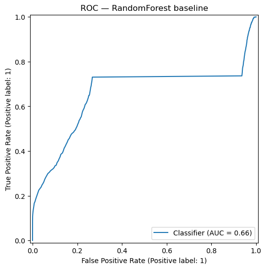

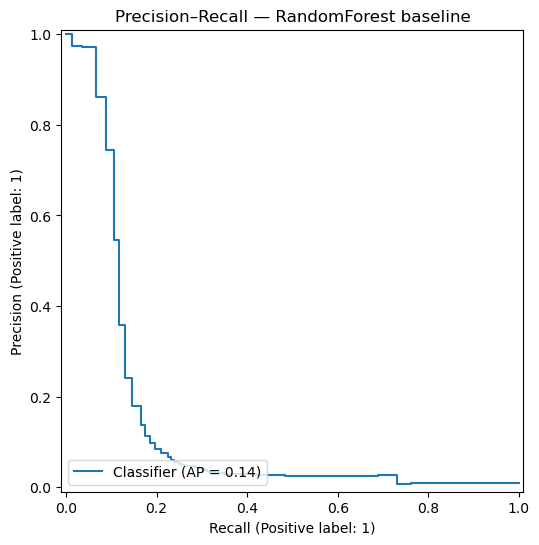

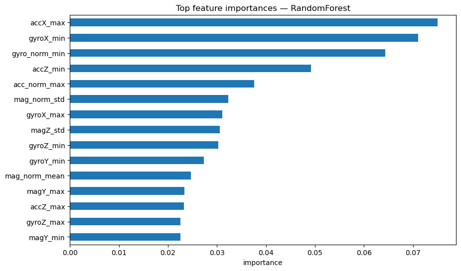

```python
# Selecting model features
from sklearn.metrics import (classification_report,confusion_matrix, roc_auc_score, average_precision_score, RocCurveDisplay, PrecisionRecallDisplay)


feat_cols_model = [c for c in dataset.columns
                   if c not in ('label','source')]

X = dataset[feat_cols_model].values
y = dataset['label'].values
groups = dataset['source'].values

# Split by file
gss = GroupShuffleSplit(n_splits=1, test_size=0.3, random_state=42)
train_idx, test_idx = next(gss.split(X, y, groups))

Xtr, Xte = X[train_idx], X[test_idx]
ytr, yte = y[train_idx], y[test_idx]

# Simple, robust and fast baseline
clf = RandomForestClassifier(n_estimators=200, random_state=0, n_jobs=-1)
clf.fit(Xtr, ytr)

pred = clf.predict(Xte)
proba = clf.predict_proba(Xte)[:,1]

print("=== Classification report (test) ===")
print(classification_report(yte, pred, digits=3))

print("=== Confusion matrix ===")
print(confusion_matrix(yte, pred))

# ROC-AUC / PR-AUC (protected if only one class is tested)
try:
    roc = roc_auc_score(yte, proba)
    pr  = average_precision_score(yte, proba)
    print(f"ROC-AUC : {roc:.3f}")
    print(f"PR-AUC  : {pr:.3f}")

    RocCurveDisplay.from_predictions(yte, proba)
    plt.title("ROC — RandomForest baseline")
    plt.show()

    PrecisionRecallDisplay.from_predictions(yte, proba)
    plt.title("Precision–Recall — RandomForest baseline")
    plt.show()
except ValueError as e:
    print("ROC/PR curves not calculable:", e)

# (Option) Top features to interpret the baseline
import pandas as pd
imp = pd.Series(clf.feature_importances_, index=feat_cols_model).sort_values(ascending=False).head(15)
plt.figure()
imp.plot(kind="barh")
plt.gca().invert_yaxis()
plt.title("Top feature importances — RandomForest")
plt.xlabel("importance")
plt.show()
```